# foodhub_eda

```python
# import libraries for data manipulation
import numpy as np
import pandas as pd

# import libraries for data visualization
import matplotlib.pyplot as plt
import seaborn as sns
```

READ DATA

```python
# read the data
df = pd.read_csv('foodhub_order.csv')
# returns the first 5 rows
df.head()
```

|  | order_id | customer_id | restaurant_name | cuisine_type | cost_of_the_order | day_of_the_week | rating | food_preparation_time | delivery_time |
| --- | --- | --- | --- | --- | --- | --- | --- | --- | --- |
| 0 | 1477147 | 337525 | Hangawi | Korean | 30.75 | Weekend | Not given | 25 | 20 |
| 1 | 1477685 | 358141 | Blue Ribbon Sushi Izakaya | Japanese | 12.08 | Weekend | Not given | 25 | 23 |
| 2 | 1477070 | 66393 | Cafe Habana | Mexican | 12.23 | Weekday | 5 | 23 | 28 |
| 3 | 1477334 | 106968 | Blue Ribbon Fried Chicken | American | 29.20 | Weekend | 3 | 25 | 15 |
| 4 | 1478249 | 76942 | Dirty Bird to Go | American | 11.59 | Weekday | 4 | 25 | 24 |

CHECK ROWS AND COLUMNS

```python
df.shape
```

```
(1898, 9)
```

CHECK THE DATA TYPES OF COLUMNS

```python
# Use info() to print a concise summary of the DataFrame
df.info()
```

```
<class 'pandas.core.frame.DataFrame'>
RangeIndex: 1898 entries, 0 to 1897
Data columns (total 9 columns):
 #   Column                 Non-Null Count  Dtype
---  ------                 --------------  -----
 0   order_id               1898 non-null   int64
 1   customer_id            1898 non-null   int64
 2   restaurant_name        1898 non-null   object
 3   cuisine_type           1898 non-null   object
 4   cost_of_the_order      1898 non-null   float64
 5   day_of_the_week        1898 non-null   object
 6   rating                 1898 non-null   object
 7   food_preparation_time  1898 non-null   int64
 8   delivery_time          1898 non-null   int64
dtypes: float64(1), int64(4), object(4)
memory usage: 133.6+ KB
```

SHOW NULL VALUES

```python
df.isnull().sum()
```

```
order_id                 0
customer_id              0
restaurant_name          0
cuisine_type             0
cost_of_the_order        0
day_of_the_week          0
rating                   0
food_preparation_time    0
delivery_time            0
dtype: int64
```

STATISTICS SUMMARY OF COLUMNS

```python
df.describe()
```

|  | order_id | customer_id | cost_of_the_order | food_preparation_time | delivery_time |
| --- | --- | --- | --- | --- | --- |
| count | 1.898000e+03 | 1898.000000 | 1898.000000 | 1898.000000 | 1898.000000 |
| mean | 1.477496e+06 | 171168.478398 | 16.498851 | 27.371970 | 24.161749 |
| std | 5.480497e+02 | 113698.139743 | 7.483812 | 4.632481 | 4.972637 |
| min | 1.476547e+06 | 1311.000000 | 4.470000 | 20.000000 | 15.000000 |
| 25% | 1.477021e+06 | 77787.750000 | 12.080000 | 23.000000 | 20.000000 |
| 50% | 1.477496e+06 | 128600.000000 | 14.140000 | 27.000000 | 25.000000 |
| 75% | 1.477970e+06 | 270525.000000 | 22.297500 | 31.000000 | 28.000000 |
| max | 1.478444e+06 | 405334.000000 | 35.410000 | 35.000000 | 33.000000 |

COUNT VALUES AND CHECK FOR UNIQUENES VALUES OF COLUMNS

```python
df['rating'].value_counts()
```

```
rating
Not given    736
5            588
4            386
3            188
Name: count, dtype: int64
```

```python
df['order_id'].nunique()
```

```
1898
```

```python
#customer id
df['customer_id'].nunique()
```

```
1200
```

```python
# restaurant name
df['restaurant_name'].nunique()
```

```
178
```

```python
# cuisine type
df['cuisine_type'].nunique()
```

```
14
```

CHECK EACH TYPE OF CUISINE

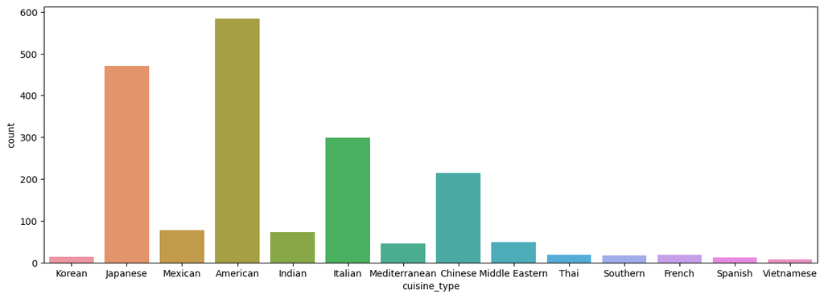

```python
# a countplot figure to show the count for each type of cuisine
plt.figure(figsize=(15,5))
sns.countplot(data=df, x='cuisine_type')
```

CHECK FOR COST OF ORDER AS HISTOGRAM

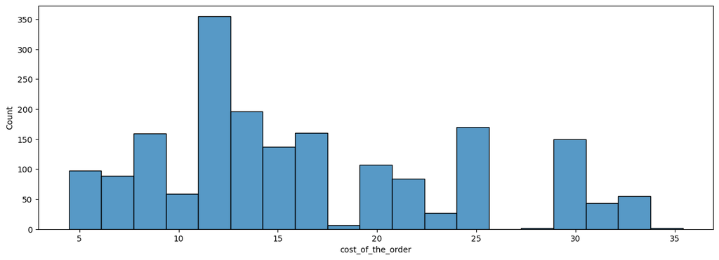

```python
# cost of order as histogram
plt.figure(figsize=(15,5))
sns.histplot(data=df, x='cost_of_the_order')
```

COST OF ORDER AS A BOXPLOT

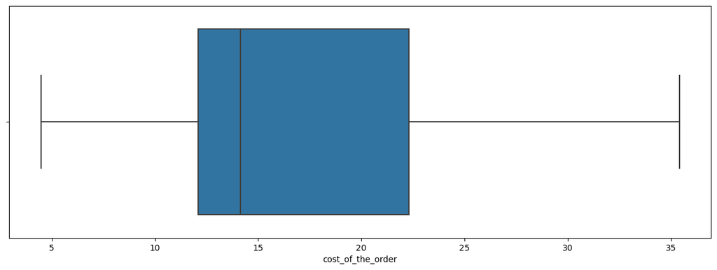

```python
# cost of order as boxplot
plt.figure(figsize=(15,5))
sns.boxplot(data=df, x='cost_of_the_order')
```

```python
# day of the week
df['day_of_the_week'].nunique()
```

```
2
```

COUNT DAYS OF THE WEEK

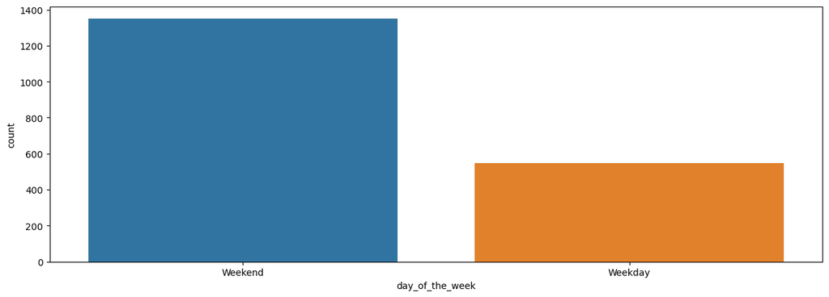

```python
# day of week as countplot
plt.figure(figsize=(15,5))
sns.countplot(data=df, x='day_of_the_week')
```

```python
# rating
df['rating'].nunique()
```

```
4
```

RATING AS COUNTPLOT

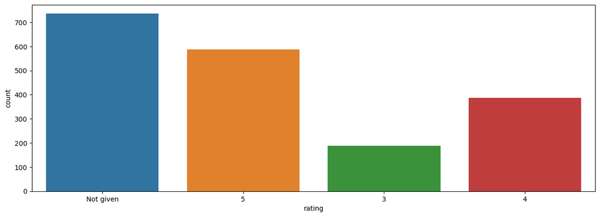

```python
# rating as countplot
plt.figure(figsize=(15,5))
sns.countplot(data=df, x='rating')
```

PREPARATION TIME AS A BOXPLOT

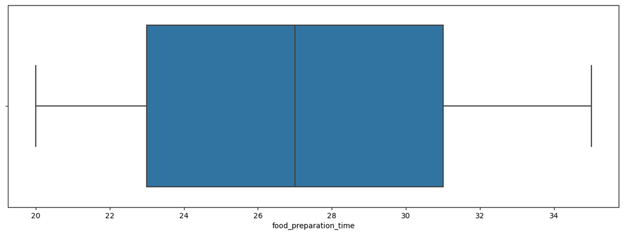

```python
# food preparation time as boxplot
plt.figure(figsize=(15,5))
sns.boxplot(data=df, x='food_preparation_time')
```

PREPARATION TIME AS A HISTPLOT

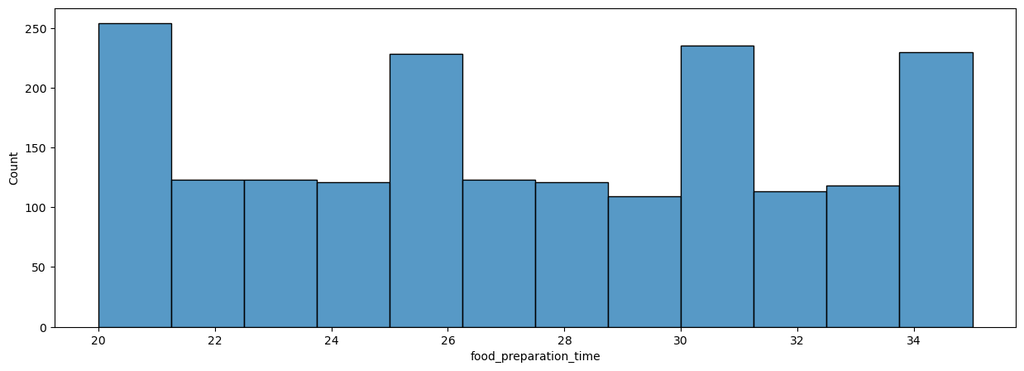

```python
# food preparation time as histpot
plt.figure(figsize=(15,5))
sns.histplot(data=df, x='food_preparation_time')
```

DELIVERY TIME AS A HISTPLOT

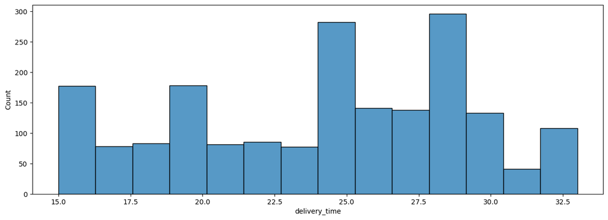

```python
# delivery time as histplot
plt.figure(figsize=(15,5))
sns.histplot(data=df, x='delivery_time')
```

DELIVERY TIME AS A BOXPLOT

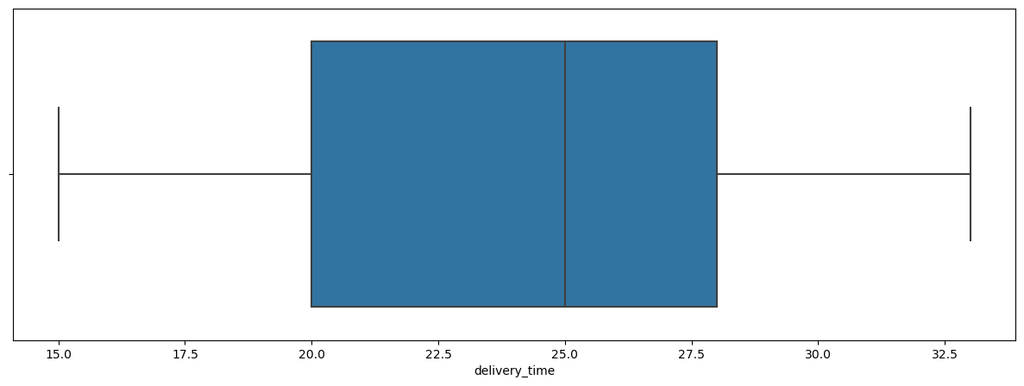

```python
# delivery time as boxplot
plt.figure(figsize=(15,5))
sns.boxplot(data=df, x='delivery_time')
```

```python
df['restaurant_name'].value_counts().head(5)
```

```
restaurant_name
Shake Shack                  219
The Meatball Shop            132
Blue Ribbon Sushi            119
Blue Ribbon Fried Chicken     96
Parm                          68
Name: count, dtype: int64
```

```python
df_weekend = df[df['day_of_the_week'] == 'Weekend']
df_weekend['cuisine_type'].value_counts().head(1)
```

```
cuisine_type
American    415
Name: count, dtype: int64
```

```python
more_than_20 = df[df['cost_of_the_order'] > 20]
percentage = (more_than_20.shape[0]/df.shape[0]) * 100
print('The percentage of the orders that cost more than 20 dollars is', round(percentage,2), '%')
```

```
The percentage of the orders that cost more than 20 dollars is 29.24 %
```

```python
avg_del_time = df['delivery_time'].mean()
print('The mean order devlivery time is', round(avg_del_time,2), 'minutes')
```

```
The mean order devlivery time is 24.16 minutes
```

```python
df['customer_id'].value_counts().head(3)
```

```
customer_id
52832    13
47440    10
83287     9
Name: count, dtype: int64
```

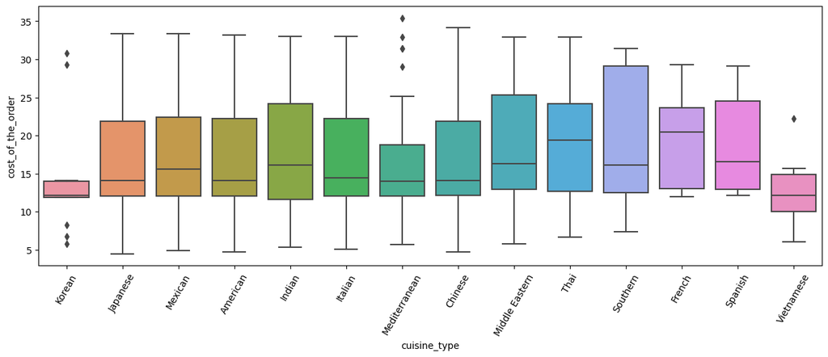

```python
#order total vs cuisine
plt.figure(figsize=(15,5))
sns.boxplot(data=df, x='cuisine_type', y='cost_of_the_order')
plt.xticks(rotation=60)
plt.show()
```

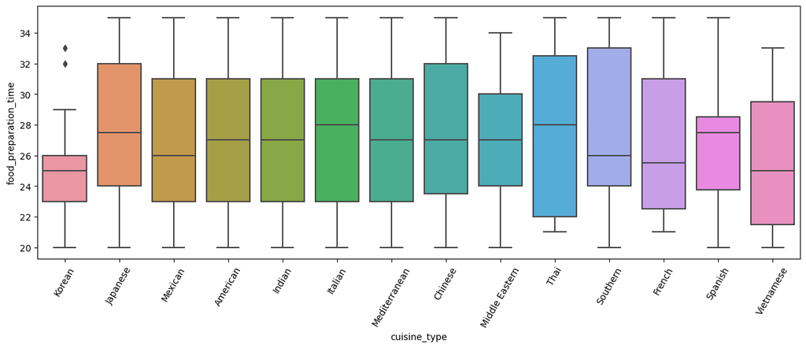

```python
#cusine vs food preparation time
plt.figure(figsize=(15,5))
sns.boxplot(data=df, x='cuisine_type', y='food_preparation_time')
plt.xticks(rotation=60)
plt.show()
```

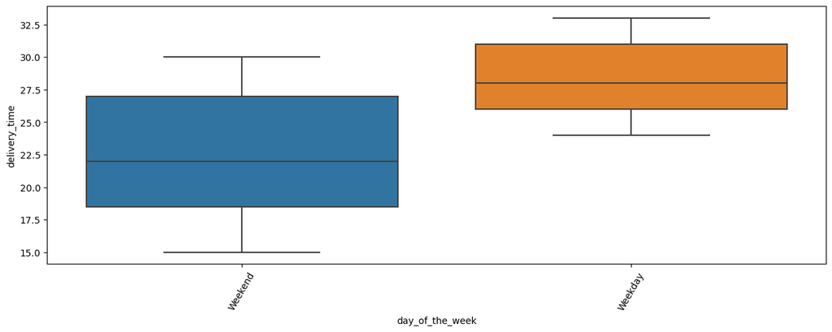

```python
#delivery time vs day
plt.figure(figsize=(15,5))
sns.boxplot(data=df, x='day_of_the_week', y='delivery_time')
plt.xticks(rotation=60)
plt.show()
```

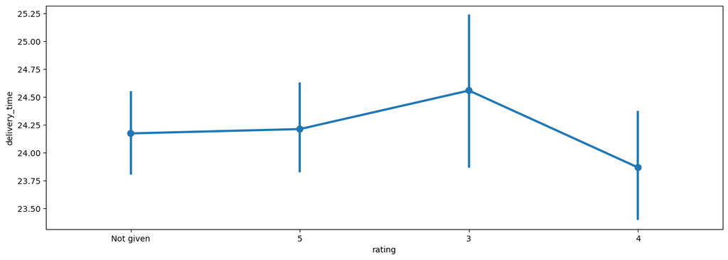

```python
#rating vs delivery time
plt.figure(figsize=(15,5))
sns.pointplot(data=df, x='rating', y='delivery_time')
plt.show()
```

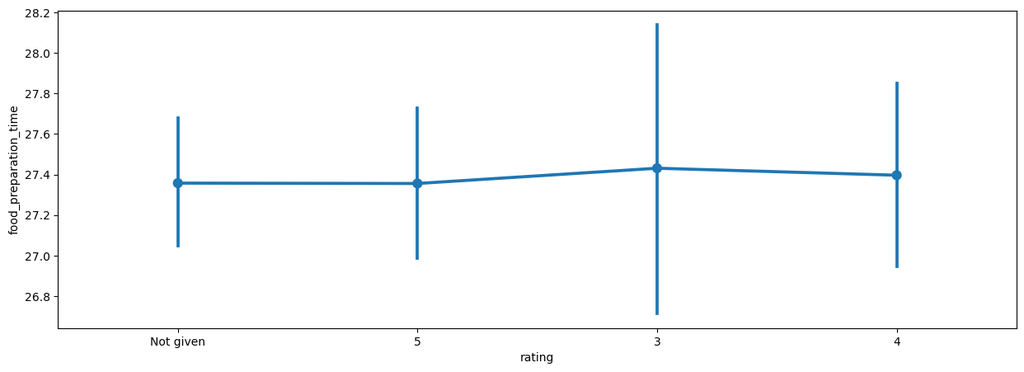

```python
#rating vs food preparation time
plt.figure(figsize=(15,5))
sns.pointplot(data=df, x='rating', y='food_preparation_time')
plt.show()
```